# Assignment

You were asked to analyse the last month of bike-sharing data in NYC (data source: https://citibikenyc.com/system-data ), and your manager thinks we could add insurance coverage for **rides that last more than 30 minutes**.

1. How many trips would be covered?
2. If your manager thinks we could charge 0.2 USD for each ride that takes longer than 30 minutes, how much revenue could we expect?
3. Your manager wants to understand the travel distance in distance buckets (0-1,2-4,4-9,10+). Please make a diagram.

Please present your analysis in a Jupyter notebook.

```python
import pyspark.sql.functions as F
from pyspark.sql import SparkSession, DataFrame
from pyspark.sql.types import FloatType, LongType
```

```python
from helpers import haversine, get_distance_bucket
from ingest import download_zip_file, extract_zip_archive
```

# Ingestion

Ingest the February 2024 data from https://citibikenyc.com/system-data and extract the zip archive. The resulting data is stored in the `/raw` folder.

```python
file_name = "202402-citibike-tripdata.csv"
download_base_url = "https://s3.amazonaws.com/tripdata"

zip_archive_path = download_zip_file(file_name, download_base_url)
```

```python
extract_zip_archive(zip_archive_path)
```

```python
# create locally hosted Spark session
spark: SparkSession = SparkSession \
        .builder \
        .master("local[*]") \
        .appName("Citibike Assignment") \
        .getOrCreate()

spark.sparkContext.setLogLevel("ERROR")
```

```
Setting default log level to "WARN".
To adjust logging level use sc.setLogLevel(newLevel). For SparkR, use setLogLevel(newLevel).
```

```
24/04/07 13:05:29 WARN NativeCodeLoader: Unable to load native-hadoop library for your platform... using builtin-java classes where applicable
```

```python
# read all csv files from "/raw" folder
df: DataFrame = spark.read.csv("raw", header=True, pathGlobFilter="*.csv")
```

## Explore the data

Check the schema, sample values and display descriptive stats

```python
df.printSchema()
```

```
root
 |-- ride_id: string (nullable = true)
 |-- rideable_type: string (nullable = true)
 |-- started_at: string (nullable = true)
 |-- ended_at: string (nullable = true)
 |-- start_station_name: string (nullable = true)
 |-- start_station_id: string (nullable = true)
 |-- end_station_name: string (nullable = true)
 |-- end_station_id: string (nullable = true)
 |-- start_lat: string (nullable = true)
 |-- start_lng: string (nullable = true)
 |-- end_lat: string (nullable = true)
 |-- end_lng: string (nullable = true)
 |-- member_casual: string (nullable = true)
```

```python
df.sample(fraction=0.1).show()
```

```
+----------------+-------------+-------------------+-------------------+--------------------+----------------+--------------------+--------------+-----------------+------------------+------------------+------------------+-------------+
|         ride_id|rideable_type|         started_at|           ended_at|  start_station_name|start_station_id|    end_station_name|end_station_id|        start_lat|         start_lng|           end_lat|           end_lng|member_casual|
+----------------+-------------+-------------------+-------------------+--------------------+----------------+--------------------+--------------+-----------------+------------------+------------------+------------------+-------------+
|15DC38D722001DDB|electric_bike|2024-02-23 09:02:12|2024-02-23 09:08:43|Court St & Nelson St|         4077.07|        3 St & 7 Ave|       3905.15|      40.67643249|      -73.99876225|        40.6703837|      -73.97839676|       member|
|0B8681DE21E08B3A|electric_bike|2024-02-20 00:35:49|2024-02-20 00:44:36|Schermerhorn St &...|         4479.10|Nevins St & Scher...|       4437.09|     40.688645363|      -73.98538208| 40.68737247650719|-73.98176059126854|       member|
|9B680981212A5AC2|electric_bike|2024-02-21 17:44:37|2024-02-21 18:00:19| Murray St & West St|         5329.08|Nevins St & Scher...|       4437.09|     40.714555025|     -74.012549639| 40.68737247650719|-73.98176059126854|       member|
|60D2A6EB968FFBFD|electric_bike|2024-02-25 14:30:47|2024-02-25 14:32:17|Schermerhorn St &...|         4479.10|Nevins St & Scher...|       4437.09|     40.688801527|     -73.985530019| 40.68737247650719|-73.98176059126854|       member|
|5D08F112552EE341|electric_bike|2024-02-22 16:43:23|2024-02-22 16:48:49|Metropolitan Ave ...|         5308.04|Graham Ave & Cons...|       5291.05|     40.715296865|     -73.960001707|         40.715143|        -73.944507|       member|
|B7D0EB6A90409B94| classic_bike|2024-02-19 12:44:02|2024-02-19 12:46:49|     1 Ave & E 18 St|         5854.09|    E 20 St & FDR Dr|       5886.13|40.73381219196632|-73.98054420948029|40.733208626522426|    -73.9756813647|       member|
|EA634FD4CE351DFA|electric_bike|2024-02-07 16:59:46|2024-02-07 17:06:16|Fort Hamilton Pkw...|         3280.04|West Drive & Pros...|       3651.04|     40.648019791|     -73.979388595|  40.6610633719006|-73.97945255041122|       member|
|4DB8C1E04BD5318F|electric_bike|2024-02-04 08:45:15|2024-02-04 08:51:44|Fort Hamilton Pkw...|         3280.04|West Drive & Pros...|       3651.04|     40.647978902|     -73.979405522|  40.6610633719006|-73.97945255041122|       member|
|46ACC3B3C22319A7|electric_bike|2024-02-12 19:44:47|2024-02-12 19:54:46|Schermerhorn St &...|         4479.10|        5 Ave & 3 St|       3987.06|     40.688718081|     -73.985568404|        40.6728155|      -73.98352355|       member|
|F46E013AF482D3BD| classic_bike|2024-02-07 16:20:03|2024-02-07 16:24:50|Gansevoort St & H...|         6072.16|Christopher St & ...|       5847.01|40.73937600789778|-74.00520807425661|       40.73291553|      -74.00711384|       member|
|164A0D22FED140B9|electric_bike|2024-02-25 02:07:43|2024-02-25 02:09:55|11 Ave & Prospect...|         3538.09|West Drive & Pros...|       3651.04|      40.65639019|     -73.977280021|  40.6610633719006|-73.97945255041122|       member|
|C97582522ADC0076|electric_bike|2024-02-22 19:56:41|2024-02-22 20:19:11|Metropolitan Ave ...|         5308.04|Prospect Pl & Und...|       4116.08|     40.715287447|      -73.96012044|        40.6769694|         -73.96579|       member|
|B9B7F5B3765F2475| classic_bike|2024-02-19 17:33:43|2024-02-19 17:46:53|     1 Ave & E 18 St|         5854.09|LaGuardia Pl & W ...|       5721.14|40.73381219196632|-73.98054420948029|       40.72917025|      -73.99810231|       member|
|E04F0E145DE48B36|electric_bike|2024-02-03 18:22:11|2024-02-03 18:26:12| E 16 St & Irving Pl|         5938.11|  Broadway & W 25 St|       6173.08|     40.735411644|     -73.988108158| 40.74286877312112|-73.98918628692627|       member|
|D745A6DA4A15CF47|electric_bike|2024-02-23 18:29:33|2024-02-23 18:39:52| 31 St & Newtown Ave|         6923.20|    Broadway & 12 St|       6901.01|     40.767226458|     -73.920907974|           40.7668|       -73.9347774|       member|
|CB04C3A8827D338B|electric_bike|2024-02-06 08:54:55|2024-02-06 09:06:54|    12 Ave & W 40 St|         6765.01|  Broadway & W 29 St|       6289.06|     40.760901928|     -74.002811074|        40.7462009|      -73.98855723|       member|
|AD484EC30BB83C39|electric_bike|2024-02-15 00:10:36|2024-02-15 00:29:36|Riverside Dr & W ...|         8018.04|Park Ave & E Trem...|       8335.02|      40.82737267|     -73.951974154|          40.84731|         -73.89981|       member|
|1A7E921A0E8B4266|electric_bike|2024-02-18 16:45:39|2024-02-18 16:53:56|     1 Ave & E 18 St|         5854.09|     E 47 St & 1 Ave|       6498.09|     40.733946681|     -73.980502963|       40.75206862|      -73.96784384|       member|
|005EDEEE0FB43DA3|electric_bike|2024-02-08 11:36:12|2024-02-08 11:39:39|  E 84 St & Park Ave|         7243.04|     E 89 St & 3 Ave|       7265.10|     40.778283119|     -73.958269477|        40.7806284|       -73.9521667|       member|
|4E77F3DAB9CE8843|electric_bike|2024-02-21 13:24:32|2024-02-21 13:28:17|Metropolitan Ave ...|         5308.04|Manhattan Ave & L...|       5442.09|     40.715265155|      -73.95998013|          40.72084|         -73.94844|       member|
+----------------+-------------+-------------------+-------------------+--------------------+----------------+--------------------+--------------+-----------------+------------------+------------------+------------------+-------------+
only showing top 20 rows
```

```python
df.describe().show()
```

```
[Stage 2:>                                                        (0 + 16) / 16]
```

```
[Stage 2:===>                                                     (1 + 15) / 16]
```

```
[Stage 2:=====================================================>   (15 + 1) / 16]
```

```
+-------+----------------+-------------+-------------------+-------------------+--------------------+------------------+--------------------+------------------+--------------------+--------------------+--------------------+--------------------+-------------+
|summary|         ride_id|rideable_type|         started_at|           ended_at|  start_station_name|  start_station_id|    end_station_name|    end_station_id|           start_lat|           start_lng|             end_lat|             end_lng|member_casual|
+-------+----------------+-------------+-------------------+-------------------+--------------------+------------------+--------------------+------------------+--------------------+--------------------+--------------------+--------------------+-------------+
|  count|         2176423|      2176423|            2176423|            2176423|             2174529|           2174529|             2171663|           2171642|             2176423|             2176423|             2175824|             2175824|      2176423|
|   mean|        Infinity|         null|               null|               null|                null| 5972.826675235973|                null| 5969.489433277202|  40.738592888730565|   -73.9724754337636|   40.73847369318048|  -73.97263405199239|         null|
| stddev|             NaN|         null|               null|               null|                null|1110.8252391018816|                null|1107.4093480173915|0.039627343818296065|0.027881646171273748|0.039514631067734604|0.027874058396423238|         null|
|    min|00000B882691F05F| classic_bike|2024-02-01 00:00:03|2024-02-01 00:00:54|    1 Ave & E 110 St|        190 Morgan|    1 Ave & E 110 St|        190 Morgan|         40.63330996|       -73.849612713|               40.57|              -73.78|       casual|
|    max|FFFFFF24460BECD0|electric_bike|2024-02-29 23:59:52|2024-03-01 21:49:59|Yankee Ferry Term...|            SYS038|Yankee Ferry Term...|            SYS038|               40.89|       -74.026879549|               40.92|              -74.19|       member|
+-------+----------------+-------------+-------------------+-------------------+--------------------+------------------+--------------------+------------------+--------------------+--------------------+--------------------+--------------------+-------------+
```

## Prepare data for analysis

```python
# cast columns into correct data types
staged_df = (
    df.withColumn("start_station_id", df.start_station_id.cast(FloatType()))
    .withColumn("end_station_id", df.end_station_id.cast(FloatType()))
    .withColumn("started_at", F.to_timestamp(df.started_at, "yyyy-MM-dd HH:mm:ss"))
    .withColumn("ended_at", F.to_timestamp(df.ended_at, "yyyy-MM-dd HH:mm:ss"))
    .withColumn("start_lat", df.start_lat.cast(FloatType()))
    .withColumn("start_lng", df.start_lng.cast(FloatType()))
    .withColumn("end_lat", df.end_lat.cast(FloatType()))
    .withColumn("end_lng", df.end_lng.cast(FloatType()))
)
```

```python
staged_df.show(10)
```

```
+----------------+-------------+-------------------+-------------------+--------------------+----------------+--------------------+--------------+---------+----------+---------+----------+-------------+
|         ride_id|rideable_type|         started_at|           ended_at|  start_station_name|start_station_id|    end_station_name|end_station_id|start_lat| start_lng|  end_lat|   end_lng|member_casual|
+----------------+-------------+-------------------+-------------------+--------------------+----------------+--------------------+--------------+---------+----------+---------+----------+-------------+
|305C7BE0B5B34D09|electric_bike|2024-02-23 17:02:15|2024-02-23 17:13:21| Murray St & West St|         5329.08|Fulton St & Adams St|       4637.06| 40.71538| -74.01263|40.692417|-73.989494|       member|
|009A4C1BA2E187DB|electric_bike|2024-02-09 08:49:28|2024-02-09 08:53:59|Morris Ave & E 16...|         8036.05|Jerome Ave & Ande...|       8061.01|40.827152| -73.91774|40.830177| -73.92875|       member|
|7263430CDB294956|electric_bike|2024-02-17 10:51:27|2024-02-17 10:55:50|Morris Ave & E 16...|         8036.05|Jerome Ave & Ande...|       8061.01| 40.82712| -73.91779|40.830177| -73.92875|       member|
|3AE36736C8C79EBC|electric_bike|2024-02-01 09:00:46|2024-02-01 09:21:20|Court St & Nelson St|         4077.07|Lafayette St & Gr...|       5422.09| 40.67626| -73.99877| 40.72028| -73.99879|       member|
|15DC38D722001DDB|electric_bike|2024-02-23 09:02:12|2024-02-23 09:08:43|Court St & Nelson St|         4077.07|        3 St & 7 Ave|       3905.15|40.676434|-73.998764|40.670383| -73.97839|       member|
|5DE0171D21A4E026|electric_bike|2024-02-29 20:53:40|2024-02-29 21:09:17|     1 Ave & E 18 St|         5854.09|Hudson Blvd W & W...|       6611.07| 40.73391| -73.98063|40.756763| -73.99972|       member|
|1F1466ACBCA41D86| classic_bike|2024-02-07 11:09:38|2024-02-07 11:13:29|    12 Ave & W 40 St|         6765.01|Hudson Blvd W & W...|       6611.07|40.760876| -74.00278|40.756763| -73.99972|       member|
|2DCE09BEFD86A058|electric_bike|2024-02-03 22:36:05|2024-02-03 22:45:08|Court St & Nelson St|         4077.07|Fulton St & Adams St|       4637.06| 40.67623|-73.998764|40.692417|-73.989494|       member|
|8675F87E213CAB13|electric_bike|2024-02-03 18:07:24|2024-02-03 18:21:02|Schermerhorn St &...|          4479.1|        3 St & 7 Ave|       3905.15| 40.68886| -73.98518|40.670383| -73.97839|       member|
|5AD859F1FA721A96| classic_bike|2024-02-19 00:10:33|2024-02-19 00:14:29| Murray St & West St|         5329.08|Church St & Worth St|       5359.13| 40.71503| -74.01246|40.716885|  -74.0065|       member|
+----------------+-------------+-------------------+-------------------+--------------------+----------------+--------------------+--------------+---------+----------+---------+----------+-------------+
only showing top 10 rows
```

```python
staged_df.printSchema()
```

```
root
 |-- ride_id: string (nullable = true)
 |-- rideable_type: string (nullable = true)
 |-- started_at: timestamp (nullable = true)
 |-- ended_at: timestamp (nullable = true)
 |-- start_station_name: string (nullable = true)
 |-- start_station_id: float (nullable = true)
 |-- end_station_name: string (nullable = true)
 |-- end_station_id: float (nullable = true)
 |-- start_lat: float (nullable = true)
 |-- start_lng: float (nullable = true)
 |-- end_lat: float (nullable = true)
 |-- end_lng: float (nullable = true)
 |-- member_casual: string (nullable = true)
```

# Solve assignment

```python
df_with_trip_duration = staged_df.withColumn(
    "trip_duration_in_minutes",
    (staged_df.ended_at.cast(LongType()) - staged_df.started_at.cast(LongType()))
    / 60,  # convert to timestamp and calculate difference, convert to minutes
)
```

```python
# filter for trips that are longer than 30 minutes
filtered_df = df_with_trip_duration.filter(df_with_trip_duration.trip_duration_in_minutes >= 30)
```

```python
filtered_df.sample(0.1).show(10)
```

```
+----------------+-------------+-------------------+-------------------+--------------------+----------------+--------------------+--------------+---------+----------+---------+----------+-------------+------------------------+
|         ride_id|rideable_type|         started_at|           ended_at|  start_station_name|start_station_id|    end_station_name|end_station_id|start_lat| start_lng|  end_lat|   end_lng|member_casual|trip_duration_in_minutes|
+----------------+-------------+-------------------+-------------------+--------------------+----------------+--------------------+--------------+---------+----------+---------+----------+-------------+------------------------+
|6D4BA51305CB3883|electric_bike|2024-02-18 18:28:40|2024-02-18 19:20:32| Broadway & Kent Ave|         5134.09|      34 Ave & 83 St|       6518.08|40.710827| -73.96809| 40.75375| -73.88423|       casual|       51.86666666666667|
|2E809E4772354CA4|electric_bike|2024-02-04 11:47:07|2024-02-04 12:20:16| W 100 St & Broadway|         7580.01|Greenwich Ave & C...|       5914.08| 40.79737| -73.97041|40.735237|-74.000275|       member|                   33.15|
|C545E307CDC994AD| classic_bike|2024-02-24 15:26:51|2024-02-24 15:58:06|    12 Ave & W 40 St|         6765.01|Little West St & ...|       5001.08|40.760876| -74.00278|40.705692| -74.01678|       member|                   31.25|
|30F7B5CBE7490C71|electric_bike|2024-02-02 17:10:58|2024-02-02 17:44:46|Court St & Nelson St|         4077.07|     9 Ave & W 18 St|       6190.08|40.676308|-73.998695|40.743176| -74.00366|       member|                    33.8|
|E31DA8312E3F7614|electric_bike|2024-02-10 18:22:53|2024-02-10 18:53:13|     E 10 St & 2 Ave|         5746.02|     E 10 St & 2 Ave|       5746.02| 40.72954| -73.98644| 40.72971|-73.986595|       member|      30.333333333333332|
|65D41BB802D80D6E|electric_bike|2024-02-27 02:31:02|2024-02-27 03:12:02|Fulton St & Willi...|         5137.11|Fulton St & Willi...|       5137.11|40.709602| -74.00655|40.709602| -74.00655|       member|                    41.0|
|285E125FF1D3223B|electric_bike|2024-02-03 18:15:37|2024-02-03 18:45:43|Milton St & Frank...|         5752.07|     3 Ave & E 62 St|       6762.04|40.729053|-73.957695|40.763126| -73.96527|       member|                    30.1|
|9A91F089495D6C66|electric_bike|2024-02-23 11:01:38|2024-02-23 11:35:57|Central Park West...|         7141.07|     E 10 St & Ave A|       5659.05| 40.77569|-73.976234| 40.72741| -73.98142|       member|       34.31666666666667|
|4B768B3CC4FCA16A|electric_bike|2024-02-10 22:15:49|2024-02-10 22:48:20| Jackson Ave & 46 Rd|         6203.02|Eastern Pkwy & Fr...|       3919.12|40.745262| -73.94737| 40.67053| -73.95822|       member|      32.516666666666666|
|4B29AF72C59150EC|electric_bike|2024-02-06 06:16:43|2024-02-06 06:49:30|MacDougal St & Wa...|         5797.01|Eastern Pkwy & Fr...|       3919.12|40.732666|-73.998566| 40.67053| -73.95822|       member|       32.78333333333333|
+----------------+-------------+-------------------+-------------------+--------------------+----------------+--------------------+--------------+---------+----------+---------+----------+-------------+------------------------+
only showing top 10 rows
```

1. How many trips would be covered?

```python
count_covered_trips = filtered_df.count()
print(f"There are {count_covered_trips:,d} covered trips with a duration greater than or equal to 30 minutes.")
```

```
[Stage 7:>                                                        (0 + 16) / 16]
```

```
[Stage 7:===>                                                     (1 + 15) / 16]
```

```
There are 96,035 covered trips with a duration greater than or equal to 30 minutes.
```

2. If your manager thinks we could charge 0.2 USD for each ride that takes longer than 30 minutes, how much revenue could we expect?

```python
expected_revenue = count_covered_trips * 0.2
print(f"We can expect a revenue of USD {expected_revenue:,.2f}.")
```

```
We can expect a revenue of USD 19,207.00.
```

3. Your manager wants to understand the travel distance in distance buckets (0-1,2-4,4-9,10+). Please make a diagram.

```python
# calculate haversine distance between coordinates to get travel distance
haversine_udf = F.udf(haversine)
df_with_distance = staged_df.withColumn(
    "distance_travelled",
    haversine_udf(
        F.col("start_lng"), F.col("start_lat"), F.col("end_lng"), F.col("end_lat")
    ),
)
```

```python
# create histogram manually with the given buckets from the assignment
distance_bucket_udf = F.udf(get_distance_bucket)
df_with_distance_buckets = df_with_distance.withColumn(
    "distance_bucket",
    distance_bucket_udf(F.col("distance_travelled")),
)
```

```python
# calculate counts by bucket
distance_hist = df_with_distance_buckets.groupBy(
    "distance_bucket"
).count()
```

```
[Stage 10:>               (0 + 16) / 16][Stage 11:>                (0 + 0) / 16]
```

```
[Stage 10:=>              (1 + 15) / 16][Stage 11:>                (0 + 1) / 16]
```

```
[Stage 11:>                                                       (0 + 16) / 16]
```

```
[Stage 16:>               (0 + 16) / 16][Stage 17:>                (0 + 0) / 16]
```

```
[Stage 16:=>              (1 + 15) / 16][Stage 17:>                (0 + 1) / 16]
```

```
[Stage 16:=>              (1 + 15) / 16][Stage 17:=>               (1 + 1) / 16]
```

```
[Stage 16:=>              (1 + 15) / 16][Stage 17:==>              (2 + 1) / 16]
```

```
[Stage 16:========>        (8 + 8) / 16][Stage 17:===>             (3 + 8) / 16]
```

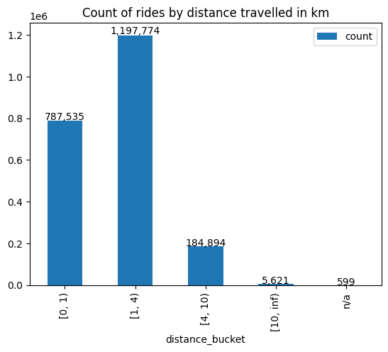

```python
import warnings

with warnings.catch_warnings():
    warnings.simplefilter(
        "ignore"
    )  # ignore the "'PYARROW_IGNORE_TIMEZONE' environment variable was not set" warning in output
    # collect data to pandas dataframe and plot it
    df_pd = distance_hist.pandas_api(index_col="distance_bucket")
df_pd_sorted = df_pd.reindex(["[0, 1)", "[1, 4)", "[4, 10)", "[10, inf)", "n/a"])
ax = df_pd_sorted.plot.bar(title="Count of rides by distance travelled in km", backend="matplotlib")

with warnings.catch_warnings():
    warnings.simplefilter(
        "ignore"
    )  # ignore the Pyspark Pandas API to_numpy() device warning in output as we expect the array to be small
    for i, val in enumerate(df_pd_sorted["count"].to_numpy()):
        ax.text(x=i, y=val * 1.005, s=f"{val:,d}", ha="center")
```